# Project 6 Report

Git In

10/18/2021

### Introduction

Birds and Mammals must maintain a consistent and elevated body temperature to permit higher metabolic output. Heterothermy in endothermic species is used to modulate metabolic demands and reduce evaporative water loss (Ostrowski, Williams, and Ismael 2003), allowing for energy conservating mechanisms such as hibernation.

Fluctuations and oscillations of body temperature ($T_b$) in mammals allow for the storing of heat during the day and loss of heat at night. Because larger animals have a greater capacitance to store energy than smaller counterparts, they require a smaller proportion of stored heat release to achieve water-loss savings. Therefore, it is expected that there will be a scaling relationship between the body temperature of humans with differing mass as well as among species with differing mass.

To investigate the scaling relationship of humans with respect to the difference between max daily $T_b$ ($T_{max}$) and minimum daily $T_b$ ($T_{min}$, or TΔ) and mass (W) as well as whether human and other mammals’ mean TΔ values scale according to mass, graphs of Delta T vs Mass were constructed in order to visualize the relationship between the variables.

### Methods

Before constructing any models or graphs, the data was log-transformed in order to investigate the percentage changes seen in the data rather than the absolute differences. To investigate whether Delta T varied with mass, linear and allometric models were constructed both for the human data only, and for the combined human and mammal data. These models were compared by calculating AIC scores for them and comparing the AIC scores using AICw. The model with the lower AIC is a better predictor; however, if the difference is less than 4, the models are roughly equivalent. Graphs of Delta T vs Mass were also constructed in order to visually see the relationship between the variables.

### Results

A plot was created showing the relationship between deltaT and mass for humans. Since the data is log-transformed and the linear model has a slight negative slope, for each increase in percent mass, there is an decrease in percent deltaT.

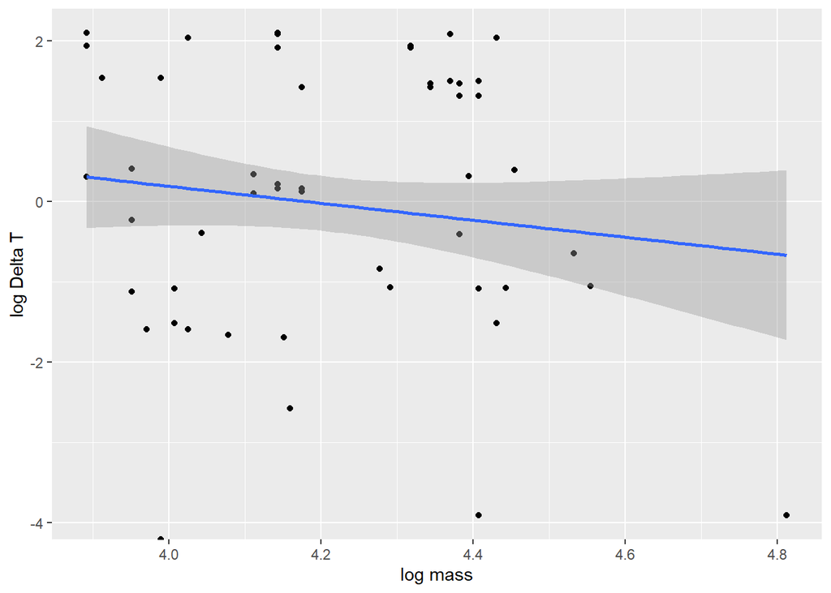

Plot of delta T vs mass for humans

A linear model of the human data was created as well as a least squares model to evaluate whether the data was isometric or allometric. An AIC was calculated for both models and AICw calculated to determine how the models compared. The AIC value for the allometric model was lower but the AIC scores were nearly equal.

```
##
## Call:
## lm(formula = temp_mean ~ mass, data = dat3)
##
## Residuals:
##      Min       1Q   Median       3Q      Max
## -0.17804 -0.06247  0.03681  0.07377  0.12465
##
## Coefficients:
##             Estimate Std. Error t value Pr(>|t|)
## (Intercept)  3.76820    0.22655  16.633   <2e-16 ***
## mass        -0.05508    0.05376  -1.025    0.309
## ---
## Signif. codes:  0 '***' 0.001 '**' 0.01 '*' 0.05 '.' 0.1 ' ' 1
##
## Residual standard error: 0.09281 on 69 degrees of freedom
##   (2 observations deleted due to missingness)
## Multiple R-squared:  0.01498,    Adjusted R-squared:  0.000709
## F-statistic:  1.05 on 1 and 69 DF,  p-value: 0.3092
```

```
##
## Formula: temp_mean ~ a * mass^b
##
## Parameters:
##   Estimate Std. Error t value Pr(>|t|)
## b -0.06797    0.06434  -1.056    0.294
## a  3.89894    0.36038  10.819   <2e-16 ***
## ---
## Signif. codes:  0 '***' 0.001 '**' 0.01 '*' 0.05 '.' 0.1 ' ' 1
##
## Residual standard error: 0.09277 on 69 degrees of freedom
##
## Number of iterations to convergence: 11
## Achieved convergence tolerance: 2.157e-08
##   (2 observations deleted due to missingness)
```

```
##         fit      delta         w
## 1 -131.7409 0.06401455 0.4919989
## 2 -131.8049 0.00000000 0.5080011
```

We created a plot of combined human and mammal data of Delta T vs Mass which shows that for the combined data set, an increase in mass corresponds to a decrease in Delta T.

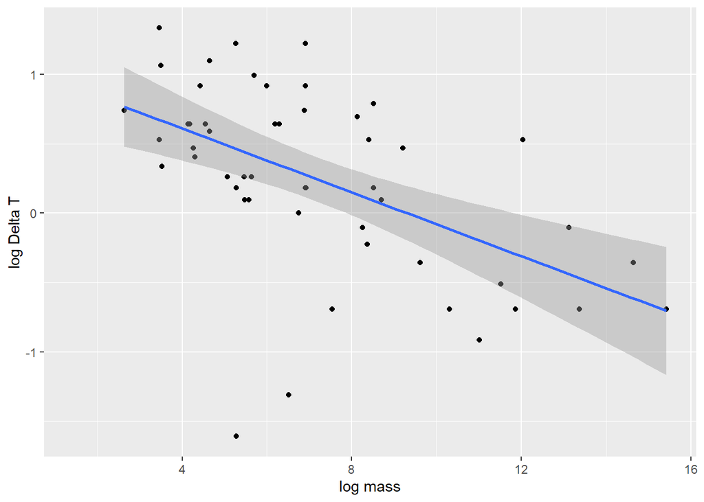

Combined Mammal and Human Delta T vs Mass

A linear model of the combined human and mammal data was created as well as a least squares model to evaluate whether the data was isometric or allometric. An AIC was calculated for both models and AICw calculated to determine how the models compared. The AIC value for the linear model was much lower so that is the better model and the data can be thought of as isometric.

```
##
## Call:
## lm(formula = deltaT ~ mass, data = dat_combined_log)
##
## Residuals:
##      Min       1Q   Median       3Q      Max
## -2.07340 -0.26858  0.01119  0.41158  0.94806
##
## Coefficients:
##             Estimate Std. Error t value Pr(>|t|)
## (Intercept)  1.07078    0.20297   5.276 2.99e-06 ***
## mass        -0.11508    0.02606  -4.416 5.53e-05 ***
## ---
## Signif. codes:  0 '***' 0.001 '**' 0.01 '*' 0.05 '.' 0.1 ' ' 1
##
## Residual standard error: 0.5693 on 49 degrees of freedom
##   (1 observation deleted due to missingness)
## Multiple R-squared:  0.2847, Adjusted R-squared:  0.2701
## F-statistic:  19.5 on 1 and 49 DF,  p-value: 5.531e-05
```

```
##
## Formula: deltaT ~ a * mass^b
##
## Parameters:
##   Estimate Std. Error t value Pr(>|t|)
## b  -1.8393     0.7243  -2.539   0.0143 *
## a   7.2838     7.4922   0.972   0.3357
## ---
## Signif. codes:  0 '***' 0.001 '**' 0.01 '*' 0.05 '.' 0.1 ' ' 1
##
## Residual standard error: 0.6071 on 49 degrees of freedom
##
## Number of iterations to convergence: 24
## Achieved convergence tolerance: 6.54e-06
##   (1 observation deleted due to missingness)
```

```
##        fit    delta          w
## 1 91.73378 0.000000 0.96384457
## 2 98.29999 6.566206 0.03615543
```

We created a plot of Delta T vs Mass by Taxonomic Group (Order) to evaluate if Order effectively predicted differences.

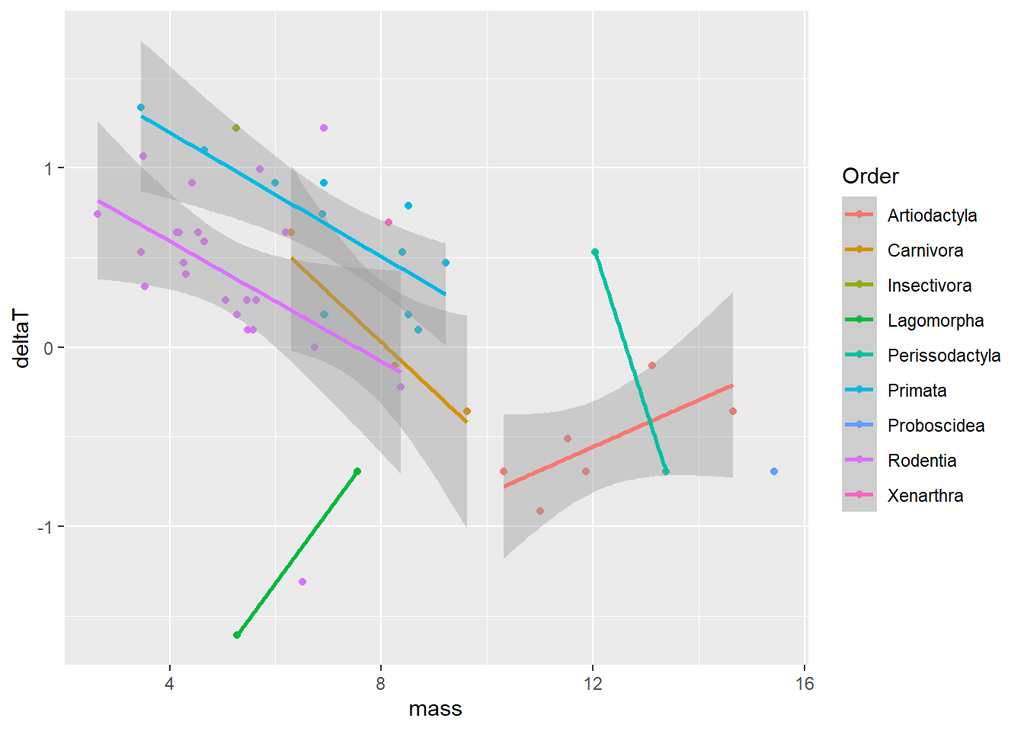

Delta T vs Mass by Order

We created a linear model that incorporated Order (lm(deltaT~mass*Order)) and performed an anova analysis on it. From the anova analysis, we can see that Order is a signficant predictor of the relationship between mass and Delta T (p = 5.224e-05 < 0.05). This means that taxonomic group with respect to order effectively predicts differences in the Delta T ~ Mass relationship across mammals.

```
## Analysis of Variance Table
##
## Response: deltaT
##            Df Sum Sq Mean Sq F value    Pr(>F)
## mass        1 6.3205  6.3205 39.9425 2.602e-07 ***
## Order       8 7.7988  0.9748  6.1605 5.224e-05 ***
## mass:Order  5 2.3834  0.4767  3.0124   0.02261 *
## Residuals  36 5.6967  0.1582
## ---
## Signif. codes:  0 '***' 0.001 '**' 0.01 '*' 0.05 '.' 0.1 ' ' 1
```

Although we can see that Order is a significant predictor of the Delta T ~ Mass relationship, we want to see if it actually fits the data better. To see this, we created two models, one with order taken into account and one without it, and ran an AIC analysis on both models. The one that took order into account had an AIC score more than ten points lower. Therefore, taking Order into account in the linear model results in a better model.

```
##        fit    delta           w
## 1 91.73378 10.79118 0.004516047
## 2 80.94260  0.00000 0.995483953
```

### References

Ostrowski, Stéphane, Joseph B Williams, and Khairi Ismael. 2003. “Heterothermy and the Water Economy of Free-Living Arabian Oryx (Oryx Leucoryx).” *Journal of Experimental Biology* 206 (9): 1471–78.